# Téma 2

2024-10-14

Nejdříve načteme dané knihovny a CSV soubor.

```r
library(dplyr)
library(ggplot2)
library(stringr)
library(sf)
library(tidyr)
data<-read.csv("NFL Play by Play 2009-2016 (v3).csv")
```

## Čištění dat

Pomocí **summarise_all** zjistíme, kolik je v každém sloupci NA (chybějících) hodnot.

```r
missing_values<-data %>% summarise_all(~ sum(is.na(.)))
print(missing_values)
```

```
##   Date GameID Drive qtr  down time TimeUnder TimeSecs PlayTimeDiff SideofField
## 1    0      0     0   0 54218    0         0      188          374         450
##   yrdln yrdline100 ydstogo ydsnet GoalToGo FirstDown posteam DefensiveTeam desc
## 1   723        723       0      0      723     25597       0         21979    0
##   PlayAttempted Yards.Gained sp Touchdown ExPointResult TwoPointConv
## 1             0            0  0         0        353399       361919
##   DefTwoPoint Safety Onsidekick PuntResult PlayType Passer Passer_ID
## 1      362433      0          0     342560        0 213358         0
##   PassAttempt PassOutcome PassLength AirYards YardsAfterCatch QBHit
## 1           0      212823     213772        0               0     0
##   PassLocation InterceptionThrown Interceptor Rusher Rusher_ID RushAttempt
## 1       213772                  0      358387 255254         0           0
##   RunLocation RunGap Receiver Receiver_ID Reception ReturnResult Returner
## 1      256187 284605   218647           0         0       346547   339535
##   BlockingPlayer Tackler1 Tackler2 FieldGoalResult FieldGoalDistance Fumble
## 1         362341   147183   318045          354431            354528      0
##   RecFumbTeam RecFumbPlayer Sack Challenge.Replay ChalReplayResult
## 1      358513        358513    0                0           359476
##   Accepted.Penalty PenalizedTeam PenaltyType PenalizedPlayer Penalty.Yards
## 1                0        336362      347849          337483             0
##   PosTeamScore DefTeamScore ScoreDiff AbsScoreDiff HomeTeam AwayTeam
## 1        23682        23682     21975        23682        0        0
##   Timeout_Indicator Timeout_Team posteam_timeouts_pre
## 1                 0            0                    0
##   HomeTimeouts_Remaining_Pre AwayTimeouts_Remaining_Pre
## 1                          0                          0
##   HomeTimeouts_Remaining_Post AwayTimeouts_Remaining_Post No_Score_Prob
## 1                           0                           0           148
##   Opp_Field_Goal_Prob Opp_Safety_Prob Opp_Touchdown_Prob Field_Goal_Prob
## 1                 148             148                148             148
##   Safety_Prob Touchdown_Prob ExPoint_Prob TwoPoint_Prob ExpPts EPA airEPA
## 1         148            148            0             0    148 322 220641
##   yacEPA Home_WP_pre Away_WP_pre Home_WP_post Away_WP_post Win_Prob  WPA airWPA
## 1 220734       21943       21943        23360        23360    21993 4817 220738
##   yacWPA Season
## 1 220956      0
```

Následně do sloupce **Date** vložíme údaje z **time**, sloupec přejmenujeme na **DateTime** a sloupec “time” smažeme.

```r
data$Date <- paste(data$Date, data$time, sep = " ")
names(data)[names(data) == "Date"] <- "DateTime"
data$time <- NULL
```

Pro cenzuru jmen využijeme funkci **str_replace_all** z balíčku *stringr*. Dataset bohužel není příliš konzistentní se zápisem jmen, tudíž následující regulární výraz nepokrývá úplně všechny možnosti, které se v něm vyskytují; stále se však jedná o většinu záznamů. Budou zcenzurovány všechny řetězce, kde Velkou iniciálu následuje tečka. a po ní buď příjmení (popřípadě prostřední jméno a až pak příjmení), anebo mezera, a až pak příjmení. Stejně tak to platí o případy, kdy je zaznamenáno hráčovo číslo ve tvaru **“#ČÍSLO”** a dále jeho příjmení ve velkých písmenech.

```r
data$desc <- str_replace_all(data$desc, "([A-Z]\\.[A-Z][a-z]+(\\s[A-Z][a-z]+)?)|(#[0-9]+\\s(([A-Z]+\\s[A-Z]+)|([A-Z][a-z]+)|([A-Z]\\.\\s?[A-Z][a-z]+)))", "CENZUROVÁNO")
```

Výběr strategie pak hledá takové řetězce v závorkách, které neobsahují čísla ve tvaru **“ČÍSLO:ČÍSLO”** anebo **“:ČÍSLO”**, řetězec **“CENZUROVÁNO”**, anebo daný řetězec z předchozího kroku.

```r
data$Strategy <- str_extract(data$desc, "\\((?!(([0-9]+)?\\:[0-9]+)|(CENZUROVÁNO)|([A-Z]\\.[A-Z][a-z]+(\\s[A-Z][a-z]+)?)|(#[0-9]+\\s(([A-Z]+\\s[A-Z]+)|([A-Z][a-z]+)|([A-Z]\\.\\s?[A-Z][a-z]+))))[^)]*\\)")
```

Při ořezu dat o řádky, které ve sloupci **“Strategy”** nemají hodnoty, zjistíme počet řádků před a po odstranění chybějících hodnot, a následně si tento procentuální výsledek vypíšeme; zjistíme, že se přišlo o více než 55 % dat.

```r
rows_before_delete <- data %>% nrow()
rows_after_delete <- data %>% drop_na(Strategy) %>% nrow()
print(((rows_before_delete - rows_after_delete)/rows_before_delete)*100)
```

```
## [1] 55.65724
```

```r
cols_before_delete <- data %>% ncol()
data2 <- data %>% select_if(~ !any(is.na(.)))
cols_after_delete <- data2 %>% ncol()
print(((cols_before_delete - cols_after_delete)/cols_before_delete)*100)
```

```
## [1] 57.84314
```

Nyní vytvoříme nové datasety/tabulky, co nahradí chybějící hodnoty. První z nich nahradí všechny chybějící hodnoty nulou, druhá použije dopředné doplňování směrem dolů, a poslední z nich průměrnou hodnotou ve sloupci. Zároveň také odstraníme všechny potenciální duplicitní řádky.

```r
data3<- data %>% replace(is.na(.), 0) %>% distinct()
data4<- fill(data, everything(), .direction = "downup") %>% distinct()
data5<- data  %>%  mutate_if(is.numeric, ~ ifelse(is.na(.), mean(., na.rm = TRUE), .)) %>% distinct()
```

## Vizualizace dat

Pomocí **is_numeric** vybereme číselné sloupce, a nad nimi provedeme požadovanou statistiku.

```r
dfnum <- data %>% select_if(is.numeric)
count_values <- colSums(!is.na(dfnum))
max_values <- dfnum %>% summarise_all(~ max(., na.rm = TRUE))
min_values <- dfnum %>% summarise_all(~ min(., na.rm = TRUE))
mean_values <- colMeans(dfnum)
sd_values <- dfnum %>% summarise_all(~ sd(., na.rm = TRUE))
```

Vzhledem k nejmenšímu počtu hodnot jsem usoudil, že nejvíc zasažené jsou následující sloupce:

### FieldGoalDistance, yacWPA & airWPA

Nyní je můžeme vykreslit v párech:

[figure not shown]

```r
ggplot(dfnum, aes(x=FieldGoalDistance, y=yacWPA)) + geom_point()
```

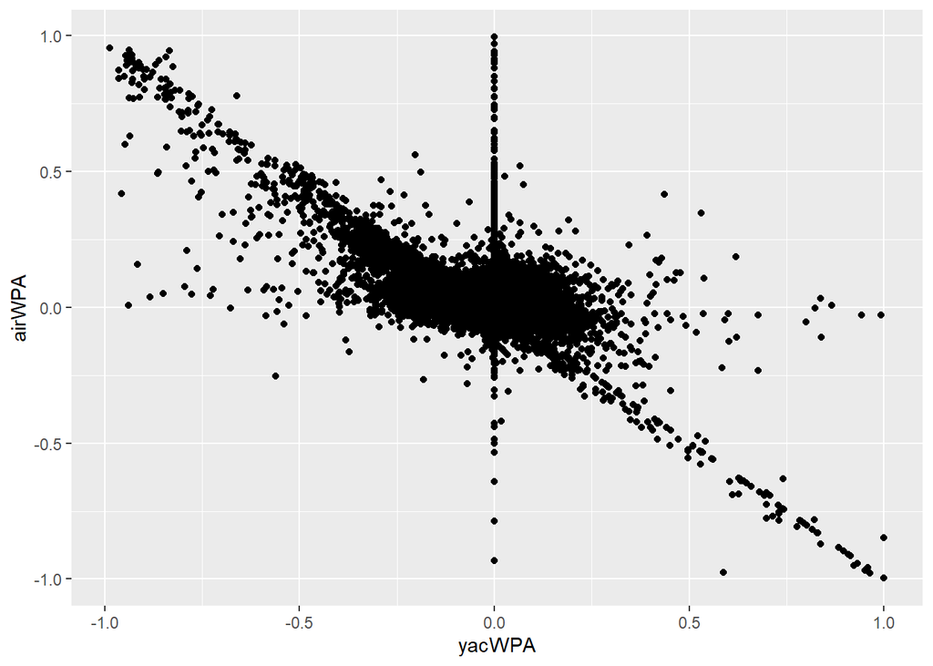

```r
ggplot(dfnum, aes(x=yacWPA, y=airWPA)) + geom_point()
```

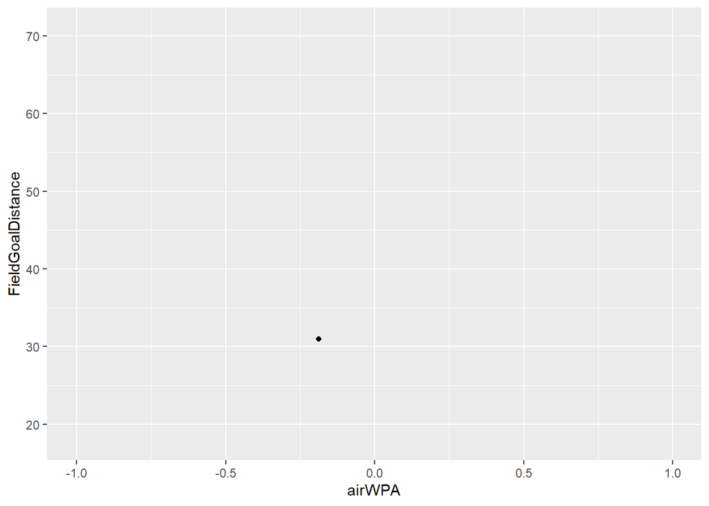

```r
ggplot(dfnum, aes(x=airWPA, y=FieldGoalDistance)) + geom_point()
```

Jelikož nás ale zajímá, jak se na nich projeví strategie řešení chybějících hodnot, vezmeme oné tři tabulky z jedné z předchozích úloh, a vybereme z nich daný sloupec. Výsledky pak spojíme do jednoho datového rámce a přiřadíme jim odpovídající strategii. Toto opakujeme pro všechny tři.

```r
field_goal <- bind_rows(
  data3 %>% select(FieldGoalDistance) %>% mutate(Strategy = "Nahrazení nulou"),
  data4 %>% select(FieldGoalDistance) %>% mutate(Strategy = "Dopředné doplnění"),
  data5 %>% select(FieldGoalDistance ) %>% mutate(Strategy = "Nahrazení průměrem")
)
yacWPA <- bind_rows(
  data3 %>% select(yacWPA) %>% mutate(Strategy = "Nahrazení nulou"),
  data4 %>% select(yacWPA) %>% mutate(Strategy = "Dopředné doplnění"),
  data5 %>% select(yacWPA ) %>% mutate(Strategy = "Nahrazení průměrem")
)
airWPA <- bind_rows(
  data3 %>% select(airWPA) %>% mutate(Strategy = "Nahrazení nulou"),
  data4 %>% select(airWPA) %>% mutate(Strategy = "Dopředné doplnění"),
  data5 %>% select(airWPA ) %>% mutate(Strategy = "Nahrazení průměrem")
)
```

Nyní již může dojít k vykreslení.

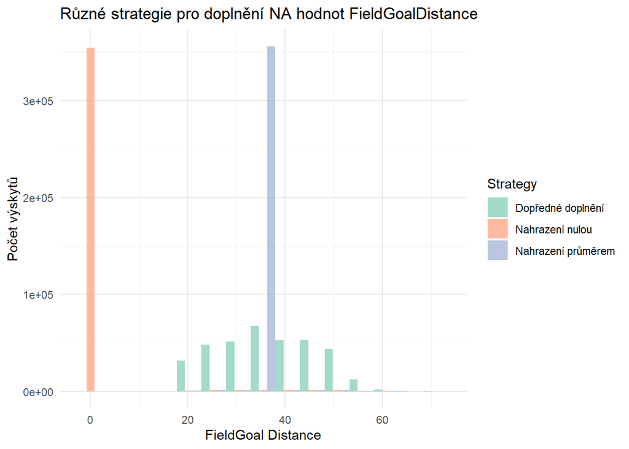

```r
ggplot(field_goal, aes(x = FieldGoalDistance, fill = Strategy)) +
  geom_histogram(position = "dodge", bins = 15, alpha = 0.6) +
  labs(title = "Různé strategie pro doplnění NA hodnot FieldGoalDistance",
       x = "FieldGoal Distance", y = "Počet výskytů") +
  theme_minimal() +
  scale_fill_brewer(palette = "Set2")
```

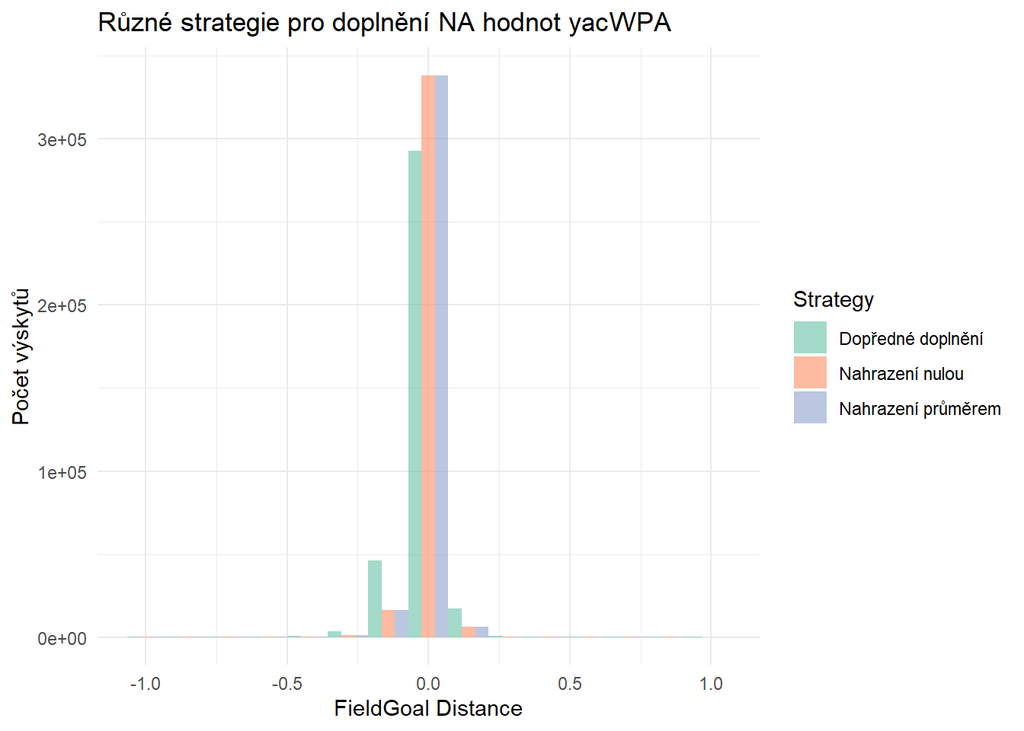

```r
ggplot(yacWPA, aes(x = yacWPA, fill = Strategy)) +
  geom_histogram(position = "dodge", bins = 15, alpha = 0.6) +
  labs(title = "Různé strategie pro doplnění NA hodnot yacWPA",
       x = "FieldGoal Distance", y = "Počet výskytů") +
  theme_minimal() +
  scale_fill_brewer(palette = "Set2")
```

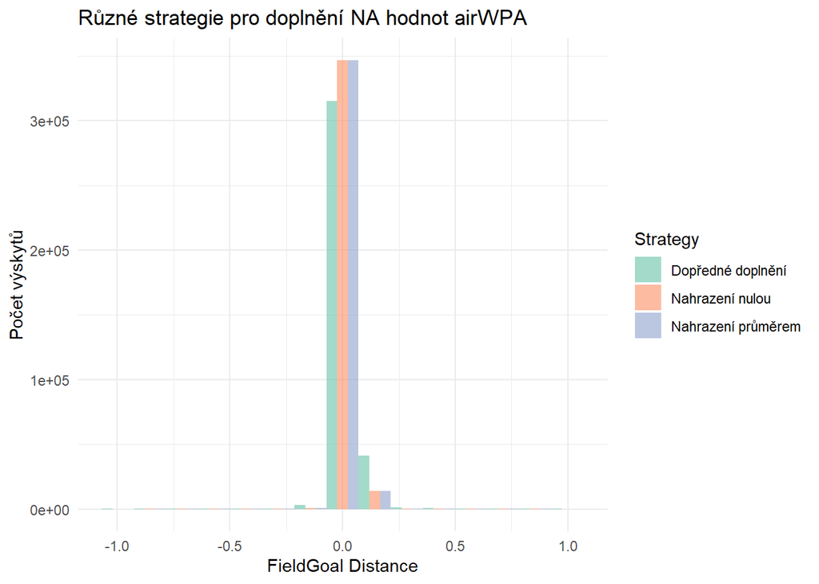

```r
ggplot(airWPA, aes(x = airWPA, fill = Strategy)) +
  geom_histogram(position = "dodge", bins = 15, alpha = 0.6) +
  labs(title = "Různé strategie pro doplnění NA hodnot airWPA",
       x = "FieldGoal Distance", y = "Počet výskytů") +
  theme_minimal() +
  scale_fill_brewer(palette = "Set2")
```

Pro snadnější zacházení se strategiemi pro ně vytvoříme nový dataframe, který bude obsahovat jejich název a odpovídající celkový počet využití. Kvůli velkému počtu dat a nízké konzistentnosti ve způsobu zápisu dat se výběr omezí na TOP12.

```r
strategies <- data.frame(data$Strategy)
colnames(strategies) <- "Strategy"
strategies <- strategies %>%
  group_by(Strategy) %>%
  summarise(`Počet výskytů` = n()) %>%
  arrange(desc(`Počet výskytů`))
strategies <- strategies %>%  slice_max(`Počet výskytů`, n = 12)
```

Nyní se již tento dataframe může vykreslit pomocí koláčového grafu, jenž ukáže podíl každé zvolené strategie.

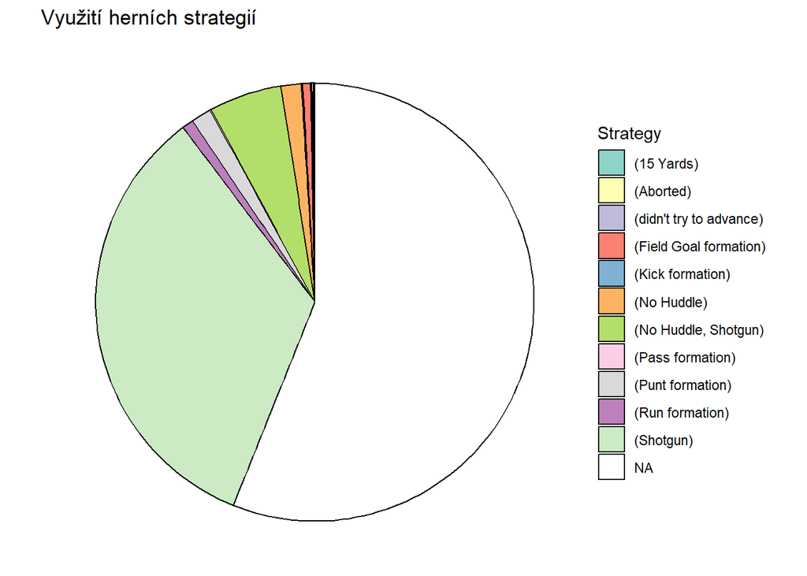

```r
ggplot(strategies, aes(x = "", y = `Počet výskytů`, fill = Strategy)) +
  geom_col(color = "black") +
  coord_polar("y", start = 0) +
  theme_void() +
  labs(title = "Využití herních strategií") +
  scale_fill_brewer(palette = "Set3")
```

Můžeme si tak povšimnout, že většina záznamů neměla danou strategii. Z těch, co měli, je pak nejvíce zastoupena strategie **Shotgun**, tvořící více než třetinu celkových záznamů. Zbytek je pak zastoupen relativně poskrovnu, v některých případech se jedná i kombinace Shotgun spolu s jinačí strategií (např. **No Huddle**).